# Ford GoBike System Data

## by (Amr saeed)

> This data set of information about individual rides made in a bike-sharing system from the greater San Francisco Bay area. this dataset consist of 183412 trip,db image taken @2019

## Investigation Overview

> In analytics, what I want is to show the analytical differences between the different elements in the available data How does the trip time affect the location of its start and the gender of the rider

## Dataset Overview

> the structure of data has 16 features and 183412 trip those are (duration_sec, start_time, end_time, start_station_id, start_station_name, start_station_latitude, start_station_longitude, end_station_id, end_station_name, end_station_latitude ,end_station_longitude, bike_id, user_type, member_birth_year, member_gender, bike_share_for_all_trip).

## conclusion

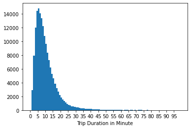

## plotting top 60 start trip distinations

### the top distnation is ("market St") & ("san francisco Station 2")

## I conclude that those two stations have the highest population so we need to provide more bikes

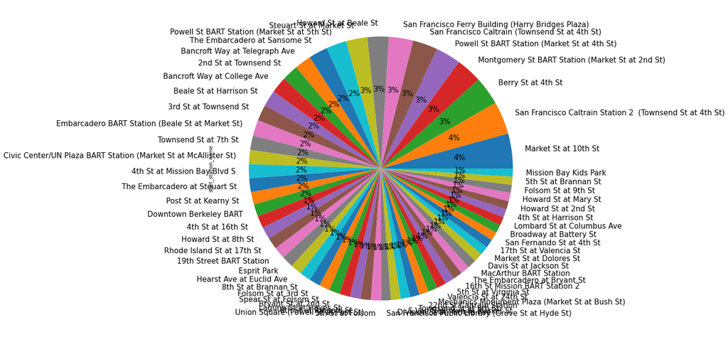

## plotting the start hour of the trip

## The trip distribution over day hours peaks around two timeframes, 7am-9am and 4pm-6pm, during typical rush hours.

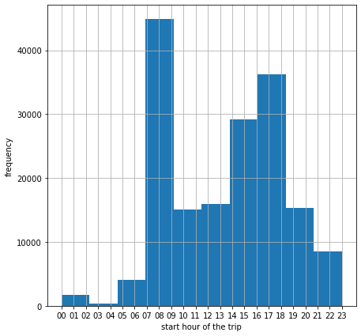

# trip duration according to each gender

## concluded that:

##### > 1- the week days are the working and collage days

##### > 2- the day hours are working start & end hours of work

##### > 3- that workers and collage students are the top clients

```
(0.0, 2000.0)
```

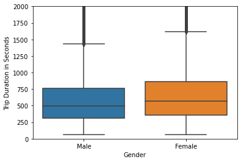

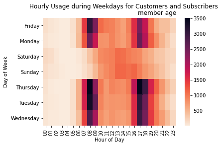

# conclusion

### the number of users for male is higher but percentage is higher for women in trip duration.

### > the week days are the working and collage days

### > the day hours are working start & end hours of work

### > that workers and collage students are the top clients

# and

### > I conclude that people avoid crowds at peak times unless the trip is a working or study trip